# Stereotyping

## Heterogeneity

### I2 overall

```r
get_I2_overall(meta_stereo1, stereo_meta1)
```

```
## [1] 91.26667
```

Again, very high.

### I2 for levels of variance

*Left value corresponds to top sigma in Variance components output in model results (Sample_number_total). Right-most value corresponds to bottom sigma (Outcome_scale group).*

```r
get_I2_levels(stereo_meta1)
```

```
## [1] 63.47 23.00  4.90
```

## Post-hoc power

- k = 138 is the number of effect sizes
- Sample size is the average found earlier to the nearest number the r function would take
- The effect sizes are from the marginal effect size outcomes

```r
subgroup_power(n_groups = 4,
               effect_sizes = c(.08, -.08, .02, -.11),
               sample_size = 100,
               k = 138,
               es_type = "d")
```

```
##
##  Power Analysis for Subgroup analysis:
##
##  Number of Groups:                  4
##  Groups:
##  Expected Effect Sizes:             0.08 -0.08 0.02 -0.11
##  Expected Sample Size (per group):  50
##  Expected Number of Studies:        138
##
##  Esimated Power to detect subgroup differences
##
##  Fixed-Effects Model:                  0.9755282
##  Random-Effects Model (i2 = 0%):       0.9755282
##  Random-Effects Model (i2 = 25%):      0.9180498
##  Random-Effects Model (i2 = 50%):      0.762756
##  Random-Effects Model (i2 = 75%):      0.441979
```

## Forest plot for model 1

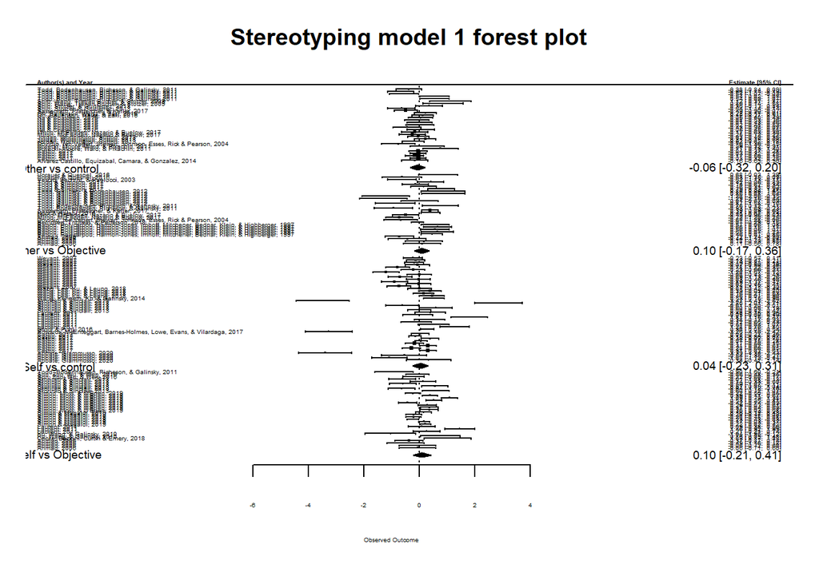

```r
par(mfrow=c(1,1))
forest(stereo_meta1,
       slab = paste(meta_stereo1$authors,
                    meta_stereo1$Year, sep = ", "),
       header="Author(s) and Year",
       main = "Stereotyping model 1 forest plot",
       ylim = c(-9, 144),
       rows = c(-8:24, 29:72, 78:107, 113:143), # self vs obj, self vs co, other vs obj, other vs c
       order = order(meta_stereo1$pt_comparison),
       addfit=FALSE,
       cex=0.3,
       top = 0)

text(x=-13, y=-11, labels=c("Self vs Objective"), cex = .6)
addpoly(x = 0.0991,
        sei = 0.160,
        ci.lb = -0.214,
        ci.ub = 0.413,
        rows = -11,
        cex = .6)

text(x=-13, y=26.5, labels=c("Self vs control"), cex = .6)
addpoly(x = 0.0419,
        sei = 0.139,
        ci.lb = -0.230,
        ci.ub = 0.314,
        rows = 26.5,
        cex = .6)

text(x=-13, y=75, labels=c("Other vs Objective"), cex = .6)
addpoly(x = 0.0980,
        sei = 0.135,
        ci.lb = -0.167,
        ci.ub = 0.363,
        rows = 75,
        cex = .6)

text(x=-13, y=110, labels=c("Other vs control"), cex = .6)
addpoly(x = -0.0592,
        sei = 0.132,
        ci.lb = -0.318,
        ci.ub = 0.200,
        rows = 110,
        cex = .6)
```

# Moderator Results 1

**Imagine self vs other model**

## Scales of measurement

```r
meta_stereo1 %>%
  group_by(pt_comparison, outcome_scale_group) %>%
  count() %>%
  filter(n <2)
```

```
## # A tibble: 2 x 3
## # Groups:   pt_comparison, outcome_scale_group [2]
##   pt_comparison    outcome_scale_group     n
##   <fct>            <fct>               <int>
## 1 self_v_objective 1                       1
## 2 self_v_control   1                       1
```

```r
#getting rid of cells with only 1
meta_stereo1_mod1_dat <- meta_stereo1 %>%
  filter(!c(pt_comparison == "self_v_objective" & outcome_scale_group == "1" |
           pt_comparison == "self_v_control" & outcome_scale_group == "1"))

stereo_meta1_mod1 <- rma.mv(dunb,
                      var_dunb,
                      mods = ~ pt_comparison*outcome_scale_group,
                      random = list(~ 1 | sample_number_total/outcomes_within_sample_var),
                      data = meta_stereo1_mod1_dat)

stereo_meta1_mod1
```

```
##
## Multivariate Meta-Analysis Model (k = 136; method: REML)
##
## Variance Components:
##
##             estim    sqrt  nlvls  fixed
## sigma^2.1  0.2471  0.4970     60     no
## sigma^2.2  0.1054  0.3247    111     no
##                                                    factor
## sigma^2.1                             sample_number_total
## sigma^2.2  sample_number_total/outcomes_within_sample_var
##
## Test for Residual Heterogeneity:
## QE(df = 117) = 608.0280, p-val < .0001
##
## Test of Moderators (coefficients 2:19):
## QM(df = 18) = 23.4807, p-val = 0.1728
##
## Model Results:
##
##                                                      estimate      se     zval
## intrcpt                                                0.4679  0.3673   1.2739
## pt_comparisonself_v_control                           -0.0861  0.2619  -0.3288
## pt_comparisonother_v_objective                        -0.5346  0.6081  -0.8791
## pt_comparisonother_v_control                          -0.2960  0.2451  -1.2075
## outcome_scale_group2                                  -0.1629  0.4471  -0.3643
## outcome_scale_group3                                  -0.5304  0.4599  -1.1532
## outcome_scale_group4                                  -0.4977  0.4197  -1.1857
## outcome_scale_group5                                   0.1625  0.4317   0.3764
## outcome_scale_group6                                  -0.2316  0.3048  -0.7599
## pt_comparisonself_v_control:outcome_scale_group2      -0.6458  0.5221  -1.2370
## pt_comparisonother_v_objective:outcome_scale_group2    0.5364  0.7332   0.7316
## pt_comparisonother_v_control:outcome_scale_group2     -0.0683  0.3927  -0.1739
## pt_comparisonself_v_control:outcome_scale_group3       0.0963  0.4297   0.2240
## pt_comparisonother_v_objective:outcome_scale_group3    0.3391  0.7567   0.4482
## pt_comparisonself_v_control:outcome_scale_group4       0.2039  0.3467   0.5880
## pt_comparisonother_v_objective:outcome_scale_group4    0.3710  0.6523   0.5688
## pt_comparisonother_v_control:outcome_scale_group4      0.3045  0.3286   0.9265
## pt_comparisonself_v_control:outcome_scale_group5       0.1466  0.4293   0.3416
## pt_comparisonother_v_objective:outcome_scale_group6    0.6828  0.5891   1.1591
```

[output cut: 8 more lines]

```
## outcome_scale_group5                                 0.7066  -0.6837  1.0087
## outcome_scale_group6                                 0.4473  -0.8289  0.3657
## pt_comparisonself_v_control:outcome_scale_group2     0.2161  -1.6692  0.3775
## pt_comparisonother_v_objective:outcome_scale_group2  0.4644  -0.9006  1.9734
## pt_comparisonother_v_control:outcome_scale_group2    0.8620  -0.8380  0.7014
## pt_comparisonself_v_control:outcome_scale_group3     0.8227  -0.7459  0.9384
## pt_comparisonother_v_objective:outcome_scale_group3  0.6540  -1.1440  1.8223
## pt_comparisonself_v_control:outcome_scale_group4     0.5565  -0.4756  0.8833
## pt_comparisonother_v_objective:outcome_scale_group4  0.5695  -0.9074  1.6494
## pt_comparisonother_v_control:outcome_scale_group4    0.3542  -0.3396  0.9486
## pt_comparisonself_v_control:outcome_scale_group5     0.7327  -0.6948  0.9881
## pt_comparisonother_v_objective:outcome_scale_group6  0.2464  -0.4718  1.8375
##
## ---
## Signif. codes:  0 '***' 0.001 '**' 0.01 '*' 0.05 '.' 0.1 ' ' 1
```

I dropped cells with only 1 study and rma.mv dropped cells with 0. Nothing is significant from one another, and the intercept is not significantly different from 0. Any model with redudancies (0’s in cells) cannot be modeled using emmeans to get marginal means.

### Heterogeneity

#### I2 overall

```r
get_I2_overall(meta_stereo1_mod1_dat, stereo_meta1_mod1)
```

```
## [1] 89.03845
```

Still very high, but slightly lower than without the moderater.

#### I2 for levels of variance

*Left value corresponds to top sigma in Variance components output in model results (Sample_number_total). Right-most value corresponds to bottom sigma (Outcome_scale group).*

```r
get_I2_var_levels(meta_stereo1_mod1_dat, stereo_meta1_mod1)
```

```
## [1] 62.41 26.63
```

Without the crossed variance structure (because it is a moderator), more of that variance shifted to the between-conditions level. Most of the variance is still represented by the between-studies level.

## Target moderator - information amount

```r
stereo_meta1_mod2 <- rma.mv(dunb,
                      var_dunb,
                      mods = ~ pt_comparison*target_information,
                      random = list(~ 1 | sample_number_total/outcomes_within_sample_var,
                                    ~ 1 | outcome_scale_group),
                      data = meta_stereo1)

stereo_meta1_mod2
```

```
##
## Multivariate Meta-Analysis Model (k = 138; method: REML)
##
## Variance Components:
##
##             estim    sqrt  nlvls  fixed
## sigma^2.1  0.4031  0.6349     61     no
## sigma^2.2  0.1137  0.3372    112     no
## sigma^2.3  0.0190  0.1380      6     no
##                                                    factor
## sigma^2.1                             sample_number_total
## sigma^2.2  sample_number_total/outcomes_within_sample_var
## sigma^2.3                             outcome_scale_group
##
## Test for Residual Heterogeneity:
## QE(df = 126) = 759.2016, p-val < .0001
##
## Test of Moderators (coefficients 2:12):
## QM(df = 11) = 14.2838, p-val = 0.2177
##
## Model Results:
##
##                                                     estimate      se     zval
## intrcpt                                              -0.0641  0.4033  -0.1589
## pt_comparisonself_v_control                          -0.1524  0.4855  -0.3139
## pt_comparisonother_v_objective                       -0.0031  0.4499  -0.0070
## pt_comparisonother_v_control                          0.2284  0.4552   0.5019
## target_information2                                   0.2889  0.4681   0.6172
## target_information3                                   0.1928  0.4860   0.3967
## pt_comparisonself_v_control:target_information2      -0.3676  0.5730  -0.6415
## pt_comparisonother_v_objective:target_information2   -0.0026  0.5304  -0.0049
## pt_comparisonother_v_control:target_information2     -0.9170  0.5472  -1.6759
## pt_comparisonself_v_control:target_information3       0.2981  0.6921   0.4308
## pt_comparisonother_v_objective:target_information3    0.0541  0.5016   0.1078
## pt_comparisonother_v_control:target_information3     -0.1511  0.5703  -0.2649
##                                                       pval    ci.lb   ci.ub
## intrcpt                                             0.8737  -0.8546  0.7264
## pt_comparisonself_v_control                         0.7536  -1.1039  0.7992
## pt_comparisonother_v_objective                      0.9944  -0.8849  0.8786
## pt_comparisonother_v_control                        0.6157  -0.6637  1.1205
## target_information2                                 0.5371  -0.6285  1.2063
## target_information3                                 0.6916  -0.7597  1.1452
## pt_comparisonself_v_control:target_information2     0.5212  -1.4907  0.7555
## pt_comparisonother_v_objective:target_information2  0.9961  -1.0422  1.0370
## pt_comparisonother_v_control:target_information2    0.0938  -1.9895  0.1554  .
## pt_comparisonself_v_control:target_information3     0.6666  -1.0583  1.6546
## pt_comparisonother_v_objective:target_information3  0.9141  -0.9290  1.0371
## pt_comparisonother_v_control:target_information3    0.7911  -1.2688  0.9667
##
## ---
## Signif. codes:  0 '***' 0.001 '**' 0.01 '*' 0.05 '.' 0.1 ' ' 1
```

Nothing is significant.

```r
qdrq_stereo1_mod2 <- qdrg(object = stereo_meta1_mod2, data = meta_stereo1)

emmeans_stereo1_mod2 <- summary(emmeans(qdrq_stereo1_mod2, "pt_comparison", "target_information"))
emmeans_stereo1_mod2
```

```
## target_information = 1:
##  pt_comparison      emmean    SE  df asymp.LCL asymp.UCL
##  self_v_objective  -0.0641 0.403 Inf    -0.855    0.7264
##  self_v_control    -0.2165 0.291 Inf    -0.787    0.3538
##  other_v_objective -0.0672 0.220 Inf    -0.499    0.3642
##  other_v_control    0.1644 0.225 Inf    -0.277    0.6060
##
## target_information = 2:
##  pt_comparison      emmean    SE  df asymp.LCL asymp.UCL
##  self_v_objective   0.2248 0.244 Inf    -0.254    0.7038
##  self_v_control    -0.2952 0.250 Inf    -0.785    0.1942
##  other_v_objective  0.2191 0.269 Inf    -0.307    0.7455
##  other_v_control   -0.4638 0.255 Inf    -0.963    0.0351
##
## target_information = 3:
##  pt_comparison      emmean    SE  df asymp.LCL asymp.UCL
##  self_v_objective   0.1287 0.278 Inf    -0.416    0.6734
##  self_v_control     0.2744 0.409 Inf    -0.527    1.0763
##  other_v_objective  0.1796 0.229 Inf    -0.269    0.6281
##  other_v_control    0.2061 0.266 Inf    -0.316    0.7278
##
## Confidence level used: 0.95
```

None of the effect sizes significantly differ from 0 when looking at the marginal main effects when broken down by target information.

### Heterogeneity

#### I2 overall

```r
get_I2_overall(meta_stereo1, stereo_meta1_mod2)
```

```
## [1] 92.36558
```

Compared to the original stereotyping model this is moderator, the overall heterogeneity is slightly higher.

#### I2 for levels of variance

*Left value corresponds to top sigma in Variance components output in model results (Sample_number_total). Right-most value corresponds to bottom sigma (Outcome_scale group).*

```r
get_I2_levels(stereo_meta1_mod2)
```

```
## [1] 69.59 19.63  3.29
```

Most of the variance is between-studies, with a somewhat significant amount explained by between-outcome (within-study) variance.

## Target moderator - target out-group

```r
stereo1_group_data <- meta_stereo1 %>%
  select(dunb, var_dunb, pt_comparison, target_out_minor, sample_number_total,
         outcomes_within_sample_var, conditions_within_sample_var, outcome_scale_group, effect_size_num) %>%
  na.omit()

stereo_meta1_mod3 <- rma.mv(dunb,
                      var_dunb,
                      mods = ~ pt_comparison*target_out_minor,
                      random = list(~ 1 | sample_number_total/outcomes_within_sample_var,
                                    ~ 1 | outcome_scale_group),
                      data = stereo1_group_data)

stereo_meta1_mod3
```

```
##
## Multivariate Meta-Analysis Model (k = 135; method: REML)
##
## Variance Components:
##
##             estim    sqrt  nlvls  fixed
## sigma^2.1  0.3686  0.6071     61     no
## sigma^2.2  0.1311  0.3621    109     no
## sigma^2.3  0.0148  0.1217      6     no
##                                                    factor
## sigma^2.1                             sample_number_total
## sigma^2.2  sample_number_total/outcomes_within_sample_var
## sigma^2.3                             outcome_scale_group
##
## Test for Residual Heterogeneity:
## QE(df = 127) = 751.9105, p-val < .0001
##
## Test of Moderators (coefficients 2:8):
## QM(df = 7) = 26.5194, p-val = 0.0004
##
## Model Results:
##
##                                                   estimate      se     zval
## intrcpt                                            -0.0316  0.2519  -0.1254
## pt_comparisonself_v_control                        -0.1853  0.2829  -0.6547
## pt_comparisonother_v_objective                      0.0685  0.2169   0.3158
## pt_comparisonother_v_control                       -0.2142  0.2799  -0.7653
## target_out_minor2                                   0.1719  0.3150   0.5456
## pt_comparisonself_v_control:target_out_minor2       0.4518  0.3383   1.3354
## pt_comparisonother_v_objective:target_out_minor2   -0.2116  0.3221  -0.6569
## pt_comparisonother_v_control:target_out_minor2     -0.1296  0.3723  -0.3482
##                                                     pval    ci.lb   ci.ub
## intrcpt                                           0.9002  -0.5254  0.4622
## pt_comparisonself_v_control                       0.5126  -0.7398  0.3693
## pt_comparisonother_v_objective                    0.7522  -0.3566  0.4936
## pt_comparisonother_v_control                      0.4441  -0.7628  0.3344
## target_out_minor2                                 0.5853  -0.4455  0.7893
## pt_comparisonself_v_control:target_out_minor2     0.1817  -0.2113  1.1148
## pt_comparisonother_v_objective:target_out_minor2  0.5112  -0.8429  0.4197
## pt_comparisonother_v_control:target_out_minor2    0.7277  -0.8593  0.6001
##
## ---
## Signif. codes:  0 '***' 0.001 '**' 0.01 '*' 0.05 '.' 0.1 ' ' 1
```

```r
qdrq_stereo1_mod3 <- qdrg(object = stereo_meta1_mod3, data = stereo1_group_data)

emmeans_stereo1_mod3 <- summary(emmeans(qdrq_stereo1_mod3, "pt_comparison", "target_out_minor"))
emmeans_stereo1_mod3
```

```
## target_out_minor = 1:
##  pt_comparison       emmean    SE  df asymp.LCL asymp.UCL
##  self_v_objective  -0.03159 0.252 Inf   -0.5254    0.4622
##  self_v_control    -0.21685 0.160 Inf   -0.5306    0.0969
##  other_v_objective  0.03689 0.190 Inf   -0.3364    0.4102
##  other_v_control   -0.24579 0.159 Inf   -0.5570    0.0654
##
## target_out_minor = 2:
##  pt_comparison       emmean    SE  df asymp.LCL asymp.UCL
##  self_v_objective   0.14028 0.204 Inf   -0.2586    0.5391
##  self_v_control     0.40680 0.166 Inf    0.0816    0.7320
##  other_v_objective -0.00283 0.200 Inf   -0.3950    0.3893
##  other_v_control   -0.20355 0.209 Inf   -0.6131    0.2060
##
## Confidence level used: 0.95
```

### Heterogeneity

#### I2 overall

```r
get_I2_overall(stereo1_group_data, stereo_meta1_mod3)
```

```
## [1] 91.95176
```

About the same as the original model without moderators.

#### I2 for levels of variance

*Left value corresponds to top sigma in Variance components output in model results (Sample_number_total). Right-most value corresponds to bottom sigma (Outcome_scale group).*

```r
get_I2_levels(stereo_meta1_mod3)
```

```
## [1] 66.01 23.48  2.65
```

## Sample size

```r
stereo_meta1_mod4 <- rma.mv(dunb,
                      var_dunb,
                      mods = ~ pt_comparison*n_overall,
                      random = list(~ 1 | sample_number_total/outcomes_within_sample_var,
                                    ~ 1 | outcome_scale_group),
                      data = meta_stereo1)

stereo_meta1_mod4
```

```
##
## Multivariate Meta-Analysis Model (k = 138; method: REML)
##
## Variance Components:
##
##             estim    sqrt  nlvls  fixed
## sigma^2.1  0.3487  0.5905     61     no
## sigma^2.2  0.1200  0.3465    112     no
## sigma^2.3  0.0326  0.1806      6     no
##                                                    factor
## sigma^2.1                             sample_number_total
## sigma^2.2  sample_number_total/outcomes_within_sample_var
## sigma^2.3                             outcome_scale_group
##
## Test for Residual Heterogeneity:
## QE(df = 130) = 785.6819, p-val < .0001
##
## Test of Moderators (coefficients 2:8):
## QM(df = 7) = 13.0674, p-val = 0.0705
##
## Model Results:
##
##                                           estimate      se     zval    pval
## intrcpt                                     0.0133  0.2345   0.0565  0.9549
## pt_comparisonself_v_control                -0.2520  0.3090  -0.8158  0.4146
## pt_comparisonother_v_objective             -0.1052  0.2245  -0.4685  0.6394
## pt_comparisonother_v_control                0.5416  0.3235   1.6742  0.0941
## n_overall                                   0.0007  0.0018   0.4256  0.6704
## pt_comparisonself_v_control:n_overall      -0.0001  0.0022  -0.0653  0.9480
## pt_comparisonother_v_objective:n_overall    0.0023  0.0023   0.9831  0.3256
## pt_comparisonother_v_control:n_overall     -0.0061  0.0029  -2.1205  0.0340
##                                             ci.lb    ci.ub
## intrcpt                                   -0.4463   0.4728
## pt_comparisonself_v_control               -0.8576   0.3535
## pt_comparisonother_v_objective            -0.5451   0.3348
## pt_comparisonother_v_control              -0.0925   1.1756  .
## n_overall                                 -0.0027   0.0042
## pt_comparisonself_v_control:n_overall     -0.0045   0.0042
## pt_comparisonother_v_objective:n_overall  -0.0023   0.0068
## pt_comparisonother_v_control:n_overall    -0.0116  -0.0005  *
##
## ---
## Signif. codes:  0 '***' 0.001 '**' 0.01 '*' 0.05 '.' 0.1 ' ' 1
```

### Heterogeneity

#### I2 overall

```r
get_I2_overall(meta_stereo1, stereo_meta1_mod4)
```

```
## [1] 91.62388
```

Heterogeneity is about the same as the model without moderators.

#### I2 for levels of variance

*Left value corresponds to top sigma in Variance components output in model results (Sample_number_total). Right-most value corresponds to bottom sigma (Outcome_scale group).*

```r
get_I2_levels(stereo_meta1_mod4)
```

```
## [1] 64.01 22.04  5.99
```

Most variance is explained by between-studies variance, followed by between-outcomes (within-study) variance.

# Stereotyping Results 2

**Model comparing “day in the life,” other control, and objective comparisons**

## Results

**Contrasts:**

```r
contrasts(meta_stereo2$pt_comparison)
```

```
##                    pt_v_other_control pt_v_objective
## pt_v_day_control                    0              0
## pt_v_other_control                  1              0
## pt_v_objective                      0              1
```

**Results:**

```r
# OVerall model across outcome type
stereo_meta2 <- rma.mv(dunb,
                      var_dunb,
                      mods = ~ pt_comparison,
                      random = list(~ 1 | sample_number_total/outcomes_within_sample_var,
                                    ~ 1 | outcome_scale_group),
                      data = meta_stereo2)

stereo_meta2
```

```
##
## Multivariate Meta-Analysis Model (k = 138; method: REML)
##
## Variance Components:
##
##             estim    sqrt  nlvls  fixed
## sigma^2.1  0.3184  0.5643     61     no
## sigma^2.2  0.1149  0.3390    112     no
## sigma^2.3  0.0265  0.1627      6     no
##                                                    factor
## sigma^2.1                             sample_number_total
## sigma^2.2  sample_number_total/outcomes_within_sample_var
## sigma^2.3                             outcome_scale_group
##
## Test for Residual Heterogeneity:
## QE(df = 135) = 788.5361, p-val < .0001
##
## Test of Moderators (coefficients 2:3):
## QM(df = 2) = 1.2278, p-val = 0.5412
##
## Model Results:
##
##                                  estimate      se     zval    pval    ci.lb
## intrcpt                            0.0015  0.1907   0.0080  0.9936  -0.3722
## pt_comparisonpt_v_other_control   -0.0312  0.2267  -0.1376  0.8905  -0.4754
## pt_comparisonpt_v_objective        0.1077  0.2114   0.5093  0.6105  -0.3067
##                                   ci.ub
## intrcpt                          0.3753
## pt_comparisonpt_v_other_control  0.4130
## pt_comparisonpt_v_objective      0.5220
##
## ---
## Signif. codes:  0 '***' 0.001 '**' 0.01 '*' 0.05 '.' 0.1 ' ' 1
```

Pairwise comparisons to compare:

- pt_v_objective to pt_v_other control

```r
anova(stereo_meta2, btt=2:3)
```

```
##
## Test of Moderators (coefficients 2:3):
## QM(df = 2) = 1.2278, p-val = 0.5412
```

They do not significantly differ.

### Adding paper

```r
# OVerall model across outcome type
stereo_meta2_auth <- rma.mv(dunb,
                      var_dunb,
                      mods = ~ pt_comparison,
                      random = list(~ 1 | authors/sample_number_total/outcomes_within_sample_var,
                                    ~ 1 | outcome_scale_group),
                      data = meta_stereo2)

stereo_meta2_auth
```

```
##
## Multivariate Meta-Analysis Model (k = 138; method: REML)
##
## Variance Components:
##
##             estim    sqrt  nlvls  fixed
## sigma^2.1  0.0000  0.0001     33     no
## sigma^2.2  0.3184  0.5643     61     no
## sigma^2.3  0.1149  0.3390    112     no
## sigma^2.4  0.0265  0.1627      6     no
##                                                            factor
## sigma^2.1                                                 authors
## sigma^2.2                             authors/sample_number_total
## sigma^2.3  authors/sample_number_total/outcomes_within_sample_var
## sigma^2.4                                     outcome_scale_group
##
## Test for Residual Heterogeneity:
## QE(df = 135) = 788.5361, p-val < .0001
##
## Test of Moderators (coefficients 2:3):
## QM(df = 2) = 1.2278, p-val = 0.5412
##
## Model Results:
##
##                                  estimate      se     zval    pval    ci.lb
## intrcpt                            0.0015  0.1907   0.0080  0.9936  -0.3722
## pt_comparisonpt_v_other_control   -0.0312  0.2267  -0.1376  0.8905  -0.4754
## pt_comparisonpt_v_objective        0.1077  0.2114   0.5093  0.6105  -0.3067
##                                   ci.ub
## intrcpt                          0.3753
## pt_comparisonpt_v_other_control  0.4130
## pt_comparisonpt_v_objective      0.5220
##
## ---
## Signif. codes:  0 '***' 0.001 '**' 0.01 '*' 0.05 '.' 0.1 ' ' 1
```

No effect again, so will not use

## Marginal main effects:

```r
qdrq_stereo2 <- qdrg(object = stereo_meta2, data = meta_stereo2)

emmeans_stereo2 <- summary(emmeans(qdrq_stereo2, "pt_comparison"))
emmeans_stereo2
```

```
##  pt_comparison        emmean    SE  df asymp.LCL asymp.UCL
##  pt_v_day_control    0.00152 0.191 Inf    -0.372     0.375
##  pt_v_other_control -0.02967 0.151 Inf    -0.326     0.266
##  pt_v_objective      0.10920 0.129 Inf    -0.144     0.362
##
## Confidence level used: 0.95
```

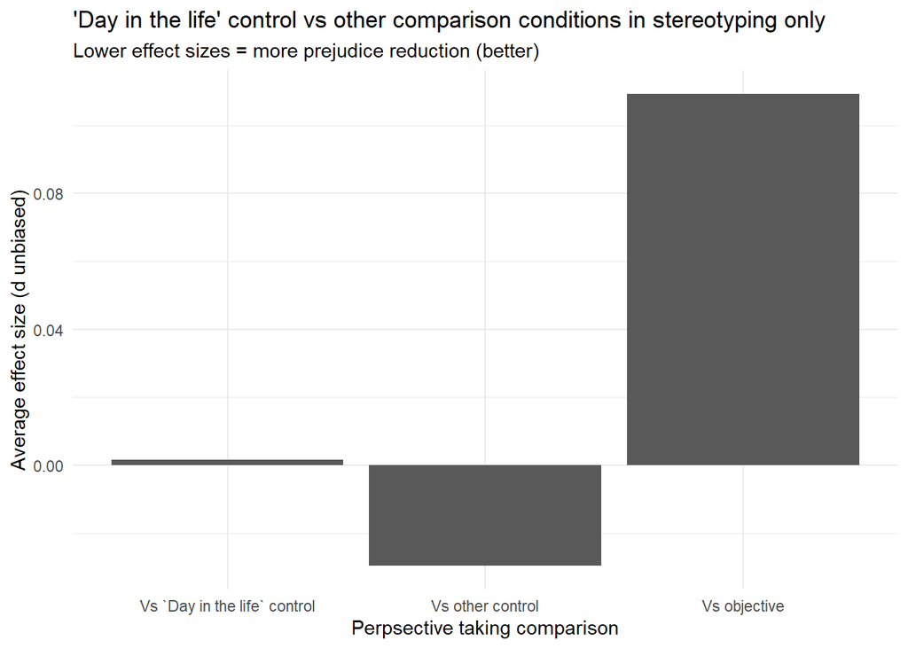

```r
emmeans_stereo2 %>% ggplot(aes(x = pt_comparison, y = emmean)) +
  geom_col() +
  theme_minimal() +
  labs(title = "'Day in the life' control vs other comparison conditions in stereotyping only",
       subtitle = "Lower effect sizes = more prejudice reduction (better)",
       x = "Perpsective taking comparison",
       y = "Average effect size (d unbiased)") +
  scale_x_discrete(labels = c('Vs `Day in the life` control','Vs other control',
                              'Vs objective'))
```

The marginal main effects do not differ from 0.

## Heterogeneity

### Overall I2

```r
get_I2_overall(meta_stereo2, stereo_meta2)
```

```
## [1] 91.32092
```

Heterogeneity is high.

### I2 for levels of variance

*Left value corresponds to top sigma in Variance components output in model results (Sample_number_total). Right-most value corresponds to bottom sigma (Outcome_scale group).*

```r
get_I2_levels(stereo_meta2)
```

```
## [1] 63.27 22.84  5.26
```

Most hetereogeneity is explained by between-study variance, followed by between-condition variance.

## Post-hoc power

- k = 138 is the number of effect sizes
- Sample size is the average found earlier to the nearest number the r function would take
- The effect sizes are from the marginal effect size outcomes

```r
subgroup_power(n_groups = 3,
               effect_sizes = c(.00, -.03, .10),
               sample_size = 99,
               k = 138,
               es_type = "d")
```

```
##
##  Power Analysis for Subgroup analysis:
##
##  Number of Groups:                  3
##  Groups:
##  Expected Effect Sizes:             0 -0.03 0.1
##  Expected Sample Size (per group):  49.5
##  Expected Number of Studies:        138
##
##  Esimated Power to detect subgroup differences
##
##  Fixed-Effects Model:                  0.8367297
##  Random-Effects Model (i2 = 0%):       0.8367297
##  Random-Effects Model (i2 = 25%):      0.7124692
##  Random-Effects Model (i2 = 50%):      0.5265937
##  Random-Effects Model (i2 = 75%):      0.2867206
```

## Forest plot for stereotyping model 2

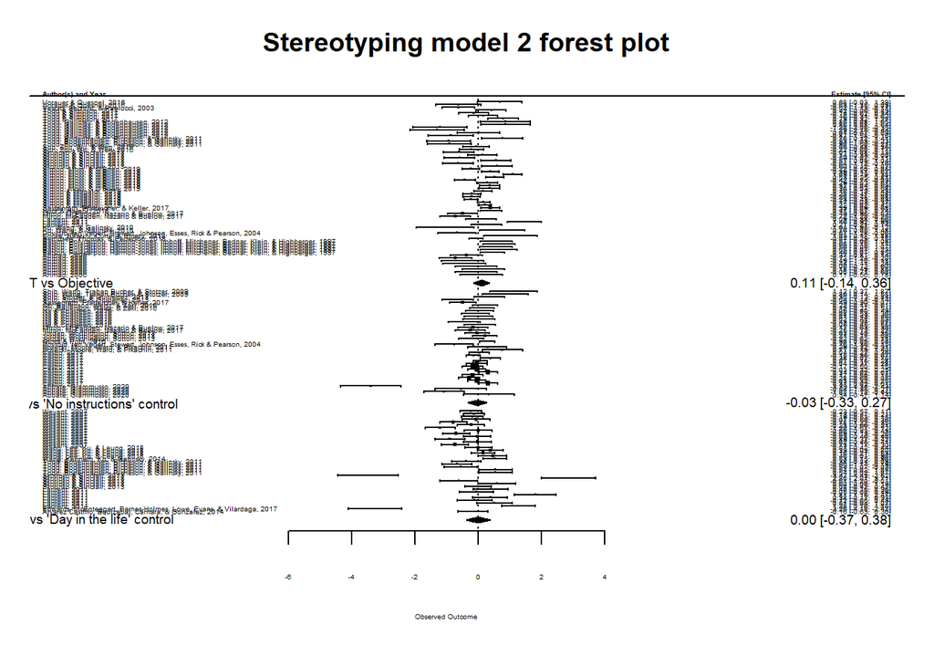

```r
forest(stereo_meta2,
       slab = paste(meta_stereo2$authors,
                    meta_stereo2$Year, sep = ", "),
       header="Author(s) and Year",
       main = "Stereotyping model 2 forest plot",
       ylim = c(-9, 140),
       rows = c(-8:28, 34:71, 77:139),
       order = order(meta_stereo2$pt_comparison),
       addfit=FALSE,
       cex=0.3,
       top = 0)

text(x=-12.2, y=-11, labels=c("PT vs 'Day in the life' control"), cex = .6)
addpoly(x = 0.00152,
        sei = 0.191,
        ci.lb = -0.372,
        ci.ub = 0.375,
        rows = -11,
        cex = .6)

text(x=-12.2, y=31, labels=c("PT vs 'No instructions' control"), cex = .6)
addpoly(x = -0.02967,
        sei = 0.151,
        ci.lb = -0.326,
        ci.ub = 0.266,
        rows = 31,
        cex = .6)

text(x=-13, y=74, labels=c("PT vs Objective"), cex = .6)
addpoly(x = 0.10920,
        sei = 0.129,
        ci.lb = -0.144,
        ci.ub = 0.362,
        rows = 74,
        cex = .6)
```

# Moderator Results 2

**Model comparing “day in the life,” other control, and objective comparisons**

## Scales of measurement

```r
stereo_meta2_mod1 <- rma.mv(dunb,
                      var_dunb,
                      mods = ~ pt_comparison*outcome_scale_group,
                      random = list(~ 1 | sample_number_total/outcomes_within_sample_var),
                      data = meta_stereo2)

stereo_meta2_mod1
```

```
##
## Multivariate Meta-Analysis Model (k = 138; method: REML)
##
## Variance Components:
##
##             estim    sqrt  nlvls  fixed
## sigma^2.1  0.3510  0.5925     61     no
## sigma^2.2  0.1290  0.3592    112     no
##                                                    factor
## sigma^2.1                             sample_number_total
## sigma^2.2  sample_number_total/outcomes_within_sample_var
##
## Test for Residual Heterogeneity:
## QE(df = 122) = 702.7946, p-val < .0001
##
## Test of Moderators (coefficients 2:16):
## QM(df = 15) = 19.7150, p-val = 0.1831
##
## Model Results:
##
##                                                       estimate      se     zval
## intrcpt                                                -0.3368  0.3675  -0.9164
## pt_comparisonpt_v_other_control                         0.1985  0.7630   0.2602
## pt_comparisonpt_v_objective                             0.2267  0.6462   0.3509
## outcome_scale_group2                                    0.4294  0.4898   0.8768
## outcome_scale_group3                                    0.1844  0.4280   0.4308
## outcome_scale_group4                                    0.4037  0.6277   0.6432
## outcome_scale_group5                                    0.8675  0.4593   1.8886
## outcome_scale_group6                                    0.0134  0.4183   0.0319
## pt_comparisonpt_v_other_control:outcome_scale_group2   -0.5471  0.8615  -0.6351
## pt_comparisonpt_v_objective:outcome_scale_group2        0.0366  0.7656   0.0479
## pt_comparisonpt_v_objective:outcome_scale_group3       -0.2017  0.7311  -0.2759
## pt_comparisonpt_v_other_control:outcome_scale_group4   -0.2840  0.9352  -0.3036
## pt_comparisonpt_v_objective:outcome_scale_group4       -0.4479  0.8424  -0.5317
## pt_comparisonpt_v_objective:outcome_scale_group5       -0.0595  0.7712  -0.0771
## pt_comparisonpt_v_other_control:outcome_scale_group6    0.0708  0.8057   0.0879
## pt_comparisonpt_v_objective:outcome_scale_group6        0.4614  0.6969   0.6621
##                                                         pval    ci.lb   ci.ub
## intrcpt                                               0.3594  -1.0571  0.3835
## pt_comparisonpt_v_other_control                       0.7947  -1.2970  1.6940
```

[output cut: 19 more lines]

```
## outcome_scale_group3
## outcome_scale_group4
## outcome_scale_group5                                  .
## outcome_scale_group6
## pt_comparisonpt_v_other_control:outcome_scale_group2
## pt_comparisonpt_v_objective:outcome_scale_group2
## pt_comparisonpt_v_objective:outcome_scale_group3
## pt_comparisonpt_v_other_control:outcome_scale_group4
## pt_comparisonpt_v_objective:outcome_scale_group4
## pt_comparisonpt_v_objective:outcome_scale_group5
## pt_comparisonpt_v_other_control:outcome_scale_group6
## pt_comparisonpt_v_objective:outcome_scale_group6
##
## ---
## Signif. codes:  0 '***' 0.001 '**' 0.01 '*' 0.05 '.' 0.1 ' ' 1
```

Nothing is significant from one another, and the intercept is not significantly different from 0. Outcome scale group 5 (Essay stereotypicality) is marginally different from the intercept outcome scale group 1 (IAT). Rma.mv dropped cells with 0 due to redundancies, and therefore cannot be modeled in emmeans.

### Heterogeneity

#### I2 overall

```r
get_I2_overall(meta_stereo2, stereo_meta2_mod1)
```

```
## [1] 91.75658
```

About the same as the model without moderators.

#### I2 for levels of variance

*Left value corresponds to top sigma in Variance components output in model results (Sample_number_total). Right-most value corresponds to bottom sigma (Outcome_scale group).*

```r
get_I2_levels(stereo_meta2_mod1)
```

```
## [1] 67.06 24.65
```

Most hetereogeneity is explained by between-studies variance, followed by between-outcomes (within-study) variance.

## Target moderator - information amount

```r
stereo_meta2_mod2 <- rma.mv(dunb,
                      var_dunb,
                      mods = ~ pt_comparison*target_information,
                      random = list(~ 1 | sample_number_total/outcomes_within_sample_var,
                                    ~ 1 | outcome_scale_group),
                      data = meta_stereo2)

stereo_meta2_mod2
```

```
##
## Multivariate Meta-Analysis Model (k = 138; method: REML)
##
## Variance Components:
##
##             estim    sqrt  nlvls  fixed
## sigma^2.1  0.3768  0.6138     61     no
## sigma^2.2  0.1144  0.3382    112     no
## sigma^2.3  0.0153  0.1235      6     no
##                                                    factor
## sigma^2.1                             sample_number_total
## sigma^2.2  sample_number_total/outcomes_within_sample_var
## sigma^2.3                             outcome_scale_group
##
## Test for Residual Heterogeneity:
## QE(df = 129) = 757.7391, p-val < .0001
##
## Test of Moderators (coefficients 2:9):
## QM(df = 8) = 14.9436, p-val = 0.0603
##
## Model Results:
##
##                                                      estimate      se     zval
## intrcpt                                               -0.1863  0.2337  -0.7973
## pt_comparisonpt_v_other_control                        0.4449  0.3312   1.3433
## pt_comparisonpt_v_objective                            0.1631  0.2971   0.5489
## target_information2                                    0.8311  0.7059   1.1774
## target_information3                                    0.4713  0.4541   1.0379
## pt_comparisonpt_v_other_control:target_information2   -1.5802  0.7798  -2.0266
## pt_comparisonpt_v_objective:target_information2       -0.6058  0.7589  -0.7982
## pt_comparisonpt_v_other_control:target_information3   -0.5343  0.5741  -0.9308
## pt_comparisonpt_v_objective:target_information3       -0.2885  0.5378  -0.5365
##                                                        pval    ci.lb    ci.ub
## intrcpt                                              0.4253  -0.6443   0.2717
## pt_comparisonpt_v_other_control                      0.1792  -0.2042   1.0940
## pt_comparisonpt_v_objective                          0.5831  -0.4192   0.7454
## target_information2                                  0.2390  -0.5524   2.2146
## target_information3                                  0.2993  -0.4187   1.3613
## pt_comparisonpt_v_other_control:target_information2  0.0427  -3.1085  -0.0519
## pt_comparisonpt_v_objective:target_information2      0.4247  -2.0932   0.8816
## pt_comparisonpt_v_other_control:target_information3  0.3520  -1.6595   0.5908
## pt_comparisonpt_v_objective:target_information3      0.5916  -1.3426   0.7655
##
## intrcpt
## pt_comparisonpt_v_other_control
## pt_comparisonpt_v_objective
## target_information2
## target_information3
## pt_comparisonpt_v_other_control:target_information2  *
## pt_comparisonpt_v_objective:target_information2
## pt_comparisonpt_v_other_control:target_information3
## pt_comparisonpt_v_objective:target_information3
##
## ---
## Signif. codes:  0 '***' 0.001 '**' 0.01 '*' 0.05 '.' 0.1 ' ' 1
```

### Marginal main effect

```r
qdrq_stereo2_mod2 <- qdrg(object = stereo_meta2_mod2, data = meta_stereo2)

emmeans_stereo2_mod2 <- summary(emmeans(qdrq_stereo2_mod2, "pt_comparison", "target_information"))
emmeans_stereo2_mod2
```

```
## target_information = 1:
##  pt_comparison       emmean    SE  df asymp.LCL asymp.UCL
##  pt_v_day_control   -0.1863 0.234 Inf    -0.644    0.2717
##  pt_v_other_control  0.2586 0.246 Inf    -0.224    0.7409
##  pt_v_objective     -0.0232 0.199 Inf    -0.414    0.3672
##
## target_information = 2:
##  pt_comparison       emmean    SE  df asymp.LCL asymp.UCL
##  pt_v_day_control    0.6448 0.670 Inf    -0.668    1.9576
##  pt_v_other_control -0.4906 0.237 Inf    -0.955   -0.0257
##  pt_v_objective      0.2021 0.209 Inf    -0.207    0.6110
##
## target_information = 3:
##  pt_comparison       emmean    SE  df asymp.LCL asymp.UCL
##  pt_v_day_control    0.2850 0.397 Inf    -0.492    1.0624
##  pt_v_other_control  0.1956 0.260 Inf    -0.313    0.7043
##  pt_v_objective      0.1596 0.216 Inf    -0.263    0.5822
##
## Confidence level used: 0.95
```

### Heterogeneity

#### I2 overall

```r
get_I2_overall(meta_stereo2, stereo_meta2_mod2)
```

```
## [1] 92.05191
```

Slightly higher than the original model without moderators.

#### I2 for levels of variance

*Left value corresponds to top sigma in Variance components output in model results (Sample_number_total). Right-most value corresponds to bottom sigma (Outcome_scale group).*

```r
get_I2_levels(stereo_meta2_mod2)
```

```
## [1] 68.52 20.81  2.78
```

Most hetereogeneity is explained by between-studies variance, followed by between-outcomes (within-study) variance.

## Target moderator - target out-group

```r
stereo2_group_data <- meta_stereo2 %>%
  select(dunb, var_dunb, pt_comparison, target_out_minor, sample_number_total,
         outcomes_within_sample_var, conditions_within_sample_var, outcome_scale_group, effect_size_num) %>%
  na.omit()

stereo_meta2_mod3 <- rma.mv(dunb,
                      var_dunb,
                      mods = ~ pt_comparison*target_out_minor,
                      random = list(~ 1 | sample_number_total/outcomes_within_sample_var,
                                    ~ 1 | outcome_scale_group),
                      data = stereo2_group_data)

stereo_meta2_mod3
```

```
##
## Multivariate Meta-Analysis Model (k = 135; method: REML)
##
## Variance Components:
##
##             estim    sqrt  nlvls  fixed
## sigma^2.1  0.3489  0.5907     61     no
## sigma^2.2  0.1318  0.3630    109     no
## sigma^2.3  0.0124  0.1114      6     no
##                                                    factor
## sigma^2.1                             sample_number_total
## sigma^2.2  sample_number_total/outcomes_within_sample_var
## sigma^2.3                             outcome_scale_group
##
## Test for Residual Heterogeneity:
## QE(df = 129) = 746.1253, p-val < .0001
##
## Test of Moderators (coefficients 2:6):
## QM(df = 5) = 29.5363, p-val < .0001
##
## Model Results:
##
##                                                    estimate      se     zval
## intrcpt                                             -0.4907  0.2118  -2.3173
## pt_comparisonpt_v_other_control                      0.5344  0.2876   1.8581
## pt_comparisonpt_v_objective                          0.5582  0.2727   2.0470
## target_out_minor2                                    0.7133  0.1349   5.2863
## pt_comparisonpt_v_other_control:target_out_minor2   -0.8412  0.2760  -3.0473
## pt_comparisonpt_v_objective:target_out_minor2       -0.6801  0.2649  -2.5676
##                                                      pval    ci.lb    ci.ub
## intrcpt                                            0.0205  -0.9057  -0.0757
## pt_comparisonpt_v_other_control                    0.0632  -0.0293   1.0981
## pt_comparisonpt_v_objective                        0.0407   0.0237   1.0928
## target_out_minor2                                  <.0001   0.4488   0.9777
## pt_comparisonpt_v_other_control:target_out_minor2  0.0023  -1.3822  -0.3001
## pt_comparisonpt_v_objective:target_out_minor2      0.0102  -1.1993  -0.1610
##
## intrcpt                                              *
## pt_comparisonpt_v_other_control                      .
## pt_comparisonpt_v_objective                          *
## target_out_minor2                                  ***
## pt_comparisonpt_v_other_control:target_out_minor2   **
## pt_comparisonpt_v_objective:target_out_minor2        *
##
## ---
## Signif. codes:  0 '***' 0.001 '**' 0.01 '*' 0.05 '.' 0.1 ' ' 1
```

The intercept (pt v day in the life control with out-group target) is significantly different from 0. Pt v control is marginally different from the intercept, and pt v objective is significantly different from the intercept. The simple main effect of target out-group group is significant: in the “day in the life” control, there are higher positive effect sizes (less prejudice reduction) for non-out-group/minority targets than out-group/minority targets. The interactions are also significant, indicating there are differences between the differences for both pt_v_control with a non-out-group minority target and p_v_objective with a non-out-group/minority target in comparison to the intercept. The marginal main effects will show the estimates of each of these comparisons better, as well as if they differ from 0.

### Marginal main effects

```r
qdrq_stereo2_mod3 <- qdrg(object = stereo_meta2_mod3, data = stereo2_group_data)

emmeans_stereo2_mod3 <- summary(emmeans(qdrq_stereo2_mod3, "pt_comparison", "target_out_minor"))
emmeans_stereo2_mod3
```

```
## target_out_minor = 1:
##  pt_comparison       emmean    SE  df asymp.LCL asymp.UCL
##  pt_v_day_control   -0.4907 0.212 Inf    -0.906   -0.0757
##  pt_v_other_control  0.0437 0.203 Inf    -0.354    0.4416
##  pt_v_objective      0.0675 0.182 Inf    -0.289    0.4241
##
## target_out_minor = 2:
##  pt_comparison       emmean    SE  df asymp.LCL asymp.UCL
##  pt_v_day_control    0.2226 0.197 Inf    -0.164    0.6090
##  pt_v_other_control -0.0842 0.180 Inf    -0.437    0.2691
##  pt_v_objective      0.1007 0.156 Inf    -0.206    0.4073
##
## Confidence level used: 0.95
```

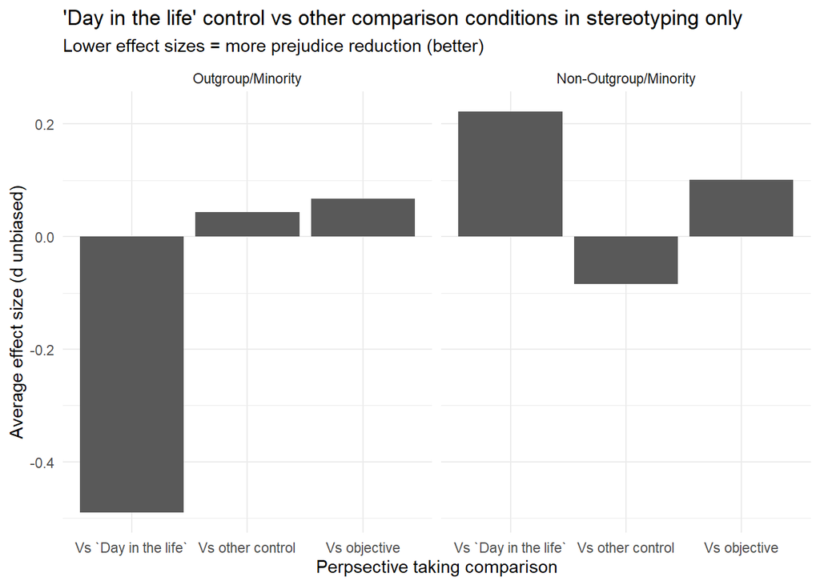

```r
outgroup_label <- c("1" = "Outgroup/Minority", "2" = "Non-Outgroup/Minority")

emmeans_stereo2_mod3 %>% ggplot(aes(x = pt_comparison, y = emmean)) +
  facet_grid(cols = vars(target_out_minor),
             labeller = labeller(target_out_minor = outgroup_label)) +
  geom_col() +
  theme_minimal() +
  labs(title = "'Day in the life' control vs other comparison conditions in stereotyping only",
       subtitle = "Lower effect sizes = more prejudice reduction (better)",
       x = "Perpsective taking comparison",
       y = "Average effect size (d unbiased)") +
  scale_x_discrete(labels = c('Vs `Day in the life`','Vs other control',
                              'Vs objective'))
```

### Heterogeneity

#### I2 overall

```r
get_I2_overall(stereo2_group_data, stereo_meta2_mod3)
```

```
## [1] 91.71436
```

About the same as the model without moderaters.

#### I2 for levels of variance

*Left value corresponds to top sigma in Variance components output in model results (Sample_number_total). Right-most value corresponds to bottom sigma (Outcome_scale group).*

```r
get_I2_levels(stereo_meta2_mod3)
```

```
## [1] 64.98 24.55  2.31
```

Most heterogeneity explained by between-studies variance, or between-conditions variance.

## Sample size

```r
stereo_meta2_mod4 <- rma.mv(dunb,
                      var_dunb,
                      mods = ~ pt_comparison*n_overall,
                      random = list(~ 1 | sample_number_total/outcomes_within_sample_var,
                                    ~ 1 | outcome_scale_group),
                      data = meta_stereo2)

stereo_meta2_mod4
```

```
##
## Multivariate Meta-Analysis Model (k = 138; method: REML)
##
## Variance Components:
##
##             estim    sqrt  nlvls  fixed
## sigma^2.1  0.3521  0.5934     61     no
## sigma^2.2  0.1147  0.3387    112     no
## sigma^2.3  0.0297  0.1724      6     no
##                                                    factor
## sigma^2.1                             sample_number_total
## sigma^2.2  sample_number_total/outcomes_within_sample_var
## sigma^2.3                             outcome_scale_group
##
## Test for Residual Heterogeneity:
## QE(df = 132) = 785.1024, p-val < .0001
##
## Test of Moderators (coefficients 2:6):
## QM(df = 5) = 5.5093, p-val = 0.3569
##
## Model Results:
##
##                                            estimate      se     zval    pval
## intrcpt                                     -0.1917  0.2908  -0.6591  0.5098
## pt_comparisonpt_v_other_control              0.3019  0.3464   0.8716  0.3834
## pt_comparisonpt_v_objective                  0.1075  0.3302   0.3254  0.7449
## n_overall                                    0.0026  0.0029   0.8752  0.3815
## pt_comparisonpt_v_other_control:n_overall   -0.0039  0.0033  -1.1668  0.2433
## pt_comparisonpt_v_objective:n_overall       -0.0005  0.0032  -0.1512  0.8798
##                                              ci.lb   ci.ub
## intrcpt                                    -0.7617  0.3784
## pt_comparisonpt_v_other_control            -0.3770  0.9807
## pt_comparisonpt_v_objective                -0.5398  0.7547
## n_overall                                  -0.0032  0.0084
## pt_comparisonpt_v_other_control:n_overall  -0.0104  0.0026
## pt_comparisonpt_v_objective:n_overall      -0.0068  0.0058
##
## ---
## Signif. codes:  0 '***' 0.001 '**' 0.01 '*' 0.05 '.' 0.1 ' ' 1
```

Sample size does not interact with pt comparison. None of the effects are significant.

### Heterogeneity

#### I2 overall

```r
get_I2_overall(meta_stereo2, stereo_meta2_mod4)
```

```
## [1] 91.72229
```

Heterogeneity is the same as in the model without moderators.

#### I2 for levels of variance

*Left value corresponds to top sigma in Variance components output in model results (Sample_number_total). Right-most value corresponds to bottom sigma (Outcome_scale group).*

```r
get_I2_levels(stereo_meta2_mod4)
```

```
## [1] 65.21 21.25  5.51
```

# Publication Bias - Egger’s Test

```r
# Getting modified covariate that removes artifactual correlation between SMD ES and its related variance
eggers_data_stereo <- meta_stereo1 %>% # Does not matter which dataset we use bc the differences between are with moderators and we are looking specifically at effect sizes and SE (or modified covariate) without moderators
    mutate(Va = 4/(n_overall),
         sda = sqrt(Va),
         sdi = sqrt(var_dunb))

# Adapted from Rodgers & Putjevosky (2019) https://osf.io/7ak2m/?view_only=e74f9ddad3834e0e8c0bae9ef6b0441c

mlma_egg_mod_sda_stereo <- rma.mv(dunb ~ 1 + sda,
                           V = var_dunb,
                           random = list(~ 1 | sample_number_total/outcomes_within_sample_var,
                                    ~ 1 | outcome_scale_group),
                           data = eggers_data_stereo, test = "t")


mlma_egg_mod_se_stereo <- rma.mv(dunb ~ 1 + sdi,
                           V = var_dunb,
                           random = list(~ 1 | sample_number_total/outcomes_within_sample_var,
                                    ~ 1 | outcome_scale_group),
                           data = eggers_data_stereo, test = "t")


mlma_results_sda_stereo <- with(mlma_egg_mod_sda_stereo,
                                 data.frame(Egger_test = "Modified Covariate",
                                                      beta = b[2],
                                                      se = se[2],
                                                      p_val = pt(zval[2], dfs, lower.tail = FALSE))) #this is the t-value

mlma_results_se_stereo <- with(mlma_egg_mod_se_stereo,
                                data.frame(Egger_test = "Standard Error",
                                                    beta = b[2],
                                                    se = se[2],
                                                    p_val = pt(zval[2], dfs, lower.tail = FALSE))) #this is the t-value

egger_stereo_results <- rbind(mlma_results_sda_stereo, mlma_results_se_stereo)
egger_stereo_results
```

```
##           Egger_test      beta        se     p_val
## 1 Modified Covariate -1.086794 1.0493960 0.8488955
## 2     Standard Error -3.303611 0.8922694 0.9998453
```

# Checking sub-sample heterogeneity

## Number of effect sizes in each scale of measurement

```r
meta_stereo1 %>%
  mutate(outcome_scale_group = dplyr::recode(outcome_scale_group,
                                                 `1` = "implicit stereo RT",
                                                 `2` = "implicit stereo other",
                                                 `3` = "stereo trait attribution or ratings",
                                                 `4` = "agreement w stereotypes toward group",
                                                 `5` = "essay stereo",
                                                 `6` = "attitudes toward target")) %>%
  count(outcome_scale_group)
```

```
## # A tibble: 6 x 2
##   outcome_scale_group                      n
## * <fct>                                <int>
## 1 implicit stereo RT                       9
## 2 implicit stereo other                   17
## 3 stereo trait attribution or ratings     30
## 4 agreement w stereotypes toward group    39
## 5 essay stereo                             8
## 6 attitudes toward target                 35
```

We will use agreement with stereotypes/prejudice toward group, as it has the most effect sizes.

### With each comparison, the cells become small though

```r
meta_stereo1 %>%
  filter(outcome_scale_group == 4) %>%
  group_by(pt_comparison) %>%
  count()
```

```
## # A tibble: 4 x 2
## # Groups:   pt_comparison [4]
##   pt_comparison         n
##   <fct>             <int>
## 1 self_v_objective     16
## 2 self_v_control        6
## 3 other_v_objective     8
## 4 other_v_control       9
```

## Meta sub-example w/ pt as moderator

```r
heterotest1_stereo <- meta_stereo1 %>%
  filter(outcome_scale_group == 4)

# Dropped crossed factor because we filtered down to one outcome
stereo_meta1_heterotest <- rma.mv(dunb,
                      var_dunb,
                      mods = ~ pt_comparison,
                      random = list(~ 1 | sample_number_total/outcomes_within_sample_var), data = heterotest1_stereo)

stereo_meta1_heterotest
```

```
##
## Multivariate Meta-Analysis Model (k = 39; method: REML)
##
## Variance Components:
##
##             estim    sqrt  nlvls  fixed
## sigma^2.1  0.0040  0.0635     16     no
## sigma^2.2  0.0825  0.2873     29     no
##                                                    factor
## sigma^2.1                             sample_number_total
## sigma^2.2  sample_number_total/outcomes_within_sample_var
##
## Test for Residual Heterogeneity:
## QE(df = 35) = 139.7795, p-val < .0001
##
## Test of Moderators (coefficients 2:4):
## QM(df = 3) = 4.9219, p-val = 0.1776
##
## Model Results:
##
##                                 estimate      se     zval    pval    ci.lb
## intrcpt                           0.1145  0.0873   1.3126  0.1893  -0.0565
## pt_comparisonself_v_control      -0.0455  0.1555  -0.2924  0.7700  -0.3503
## pt_comparisonother_v_objective   -0.3334  0.1600  -2.0842  0.0371  -0.6470
## pt_comparisonother_v_control     -0.1709  0.1419  -1.2047  0.2283  -0.4490
##                                   ci.ub
## intrcpt                          0.2856
## pt_comparisonself_v_control      0.2594
## pt_comparisonother_v_objective  -0.0199  *
## pt_comparisonother_v_control     0.1071
##
## ---
## Signif. codes:  0 '***' 0.001 '**' 0.01 '*' 0.05 '.' 0.1 ' ' 1
```

### Heterogeneity

#### Overall

```r
get_I2_overall(heterotest1_stereo, stereo_meta1_heterotest)
```

```
## [1] 75.02297
```

#### Levels

```r
get_I2_levels(stereo_meta1_heterotest)
```

```
## [1]  3.52 71.96
```

### Post-hoc power

```r
heterotest1_stereo %>%
  dplyr::select(n_pt, n_comparison) %>%
  unique() %>%
  summarise(mean(n_pt),
            mean(n_comparison))
```

```
## # A tibble: 1 x 2
##   `mean(n_pt)` `mean(n_comparison)`
##          <dbl>                <dbl>
## 1         66.1                 67.3
```

**Rounded up on sample size because “sample size must be a multiple of n_groups.”**

```r
subgroup_power(n_groups = 4,
               effect_sizes = c(.12, -.08, -.34, -.22),
               sample_size = 68,
               k = 39,
               es_type = "d")
```

```
##
##  Power Analysis for Subgroup analysis:
##
##  Number of Groups:                  4
##  Groups:
##  Expected Effect Sizes:             0.12 -0.08 -0.34 -0.22
##  Expected Sample Size (per group):  34
##  Expected Number of Studies:        39
##
##  Esimated Power to detect subgroup differences
##
##  Fixed-Effects Model:                  0.9709098
##  Random-Effects Model (i2 = 0%):       0.9709098
##  Random-Effects Model (i2 = 25%):      0.9078902
##  Random-Effects Model (i2 = 50%):      0.7465128
##  Random-Effects Model (i2 = 75%):      0.4281408
```

## Meta sub-example w/ one pt instruction

```r
heterotest2_stereo <- heterotest1_stereo %>%
  filter(pt_comparison == "self_v_objective")

# Dropped crossed factor and conditions because we filtered down to one outcome and instruction type
stereo_meta1_heterotest2 <- rma.mv(dunb,
                      var_dunb,
                      random = list(~ 1 | sample_number_total/outcomes_within_sample_var), data = heterotest2_stereo)

stereo_meta1_heterotest2
```

```
##
## Multivariate Meta-Analysis Model (k = 16; method: REML)
##
## Variance Components:
##
##             estim    sqrt  nlvls  fixed
## sigma^2.1  0.0146  0.1210      5     no
## sigma^2.2  0.1194  0.3455     16     no
##                                                    factor
## sigma^2.1                             sample_number_total
## sigma^2.2  sample_number_total/outcomes_within_sample_var
##
## Test for Heterogeneity:
## Q(df = 15) = 100.0893, p-val < .0001
##
## Model Results:
##
## estimate      se    zval    pval    ci.lb   ci.ub
##   0.1154  0.1113  1.0371  0.2997  -0.1027  0.3334
##
## ---
## Signif. codes:  0 '***' 0.001 '**' 0.01 '*' 0.05 '.' 0.1 ' ' 1
```

### Heterogeneity

#### Overall

```r
get_I2_overall(heterotest2_stereo, stereo_meta1_heterotest2)
```

```
## [1] 86.64325
```

#### Levels

```r
get_I2_levels(stereo_meta1_heterotest2)
```

```
## [1]  9.46 77.18
```

Heterogeneity goes back up… We did not remove “outcomes_within_sample_var” because some studies did include two multiple related measures (agreement with prejudice and stereotyping). Apparently there is some heterogeneity between these measures.

### Post-hoc power

```r
heterotest2_stereo %>%
  dplyr::select(n_pt, n_comparison) %>%
  unique() %>%
  summarise(mean(n_pt),
            mean(n_comparison))
```

```
## # A tibble: 1 x 2
##   `mean(n_pt)` `mean(n_comparison)`
##          <dbl>                <dbl>
## 1         95.6                   96
```

Code below did not work. However, author had a shiny app using same code, so using that with the below data we found that power at approximately 85% heterogeneity is incredibly low: 0.15.

Shiny app: https://jason-griffin.shinyapps.io/shiny_metapower/

```r
mpower(effect_size = .11, study_size = 181, k = 16, i2 = .86, es_type= "d",
       test_type = "two-tailed", p = 0.05)
```